# Homework II

Parker Lutz

June 15, 2017

#### a. Construct the dissimilarity matrix based on the Euclidian distance.

```r
clusterData <- cbind(c(1, 1, 0, 5, 6, 4), c(4, 3, 4, 1, 2, 0))
library(cluster)
dis_mat <- daisy(clusterData, metric = "euclidean", stand = FALSE)
dis_mat
```

```
FALSE Dissimilarities :
FALSE          1        2        3        4        5
FALSE 2 1.000000
FALSE 3 1.000000 1.414214
FALSE 4 5.000000 4.472136 5.830952
FALSE 5 5.385165 5.099020 6.324555 1.414214
FALSE 6 5.000000 4.242641 5.656854 1.414214 2.828427
FALSE
FALSE Metric :  euclidean
FALSE Number of objects : 6
```

#### b. Construct the Dendrogram based on complete linkage.

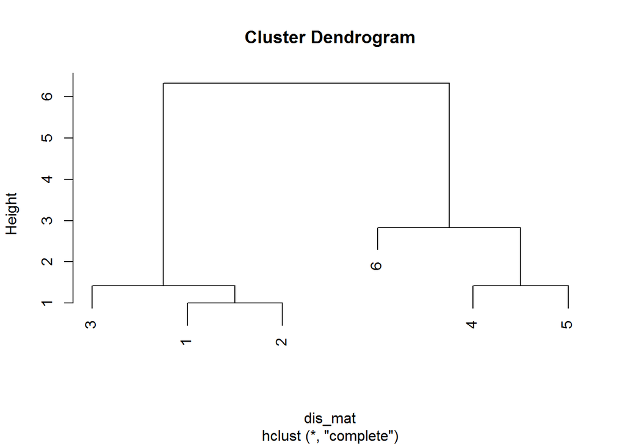

```r
comp_dend <- hclust(dis_mat, method = "complete")
plot(comp_dend)
```

#### c. Construct the Dendrogram based on average linkage.

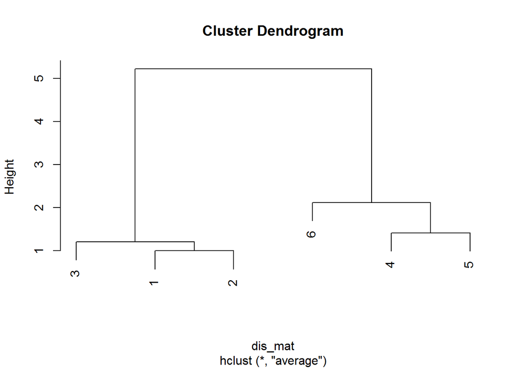

```r
avg_dend <- hclust(dis_mat, method = "average")
plot(avg_dend)
```

#### d. Calculate the CH index for the K-means clustering with K=2

```r
library(fpc)
km <- kmeans(clusterData,2)
calinhara(clusterData,km$cluster)
```

```
FALSE [1] 29.125
```

#### Complete Question 9 on page 416, “An introduction to Statistical Learning”.

#### In addition, perform the K-means clustering and choose K according to the CH index.

#### Using the command “table”, compare the result with what you find from the Hierarchical clustering

#### in part (a) (cutting the dendrogram at the same number of clusters).

#### a) Using hierarchical clustering with complete linkage and Euclidean distance, cluster the states.

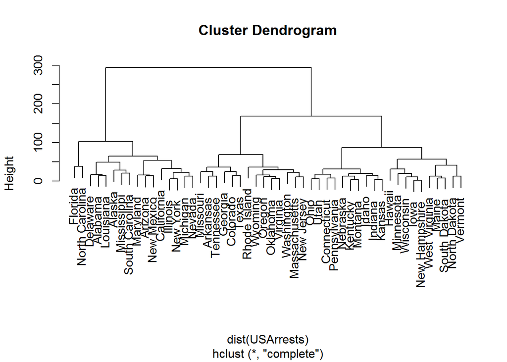

```r
set.seed(2)
hc_all <- hclust(dist(USArrests), method = "complete")
plot(hc_all)
```

#### b) Cut the dendrogram at a height that results in three distinct clusters. Which states belong to which clusters ?

```r
cut3 <- cutree(hc_all, 3)
cut3
```

```
FALSE        Alabama         Alaska        Arizona       Arkansas     California
FALSE              1              1              1              2              1
FALSE       Colorado    Connecticut       Delaware        Florida        Georgia
FALSE              2              3              1              1              2
FALSE         Hawaii          Idaho       Illinois        Indiana           Iowa
FALSE              3              3              1              3              3
FALSE         Kansas       Kentucky      Louisiana          Maine       Maryland
FALSE              3              3              1              3              1
FALSE  Massachusetts       Michigan      Minnesota    Mississippi       Missouri
FALSE              2              1              3              1              2
FALSE        Montana       Nebraska         Nevada  New Hampshire     New Jersey
FALSE              3              3              1              3              2
FALSE     New Mexico       New York North Carolina   North Dakota           Ohio
FALSE              1              1              1              3              3
FALSE       Oklahoma         Oregon   Pennsylvania   Rhode Island South Carolina
FALSE              2              2              3              2              1
FALSE   South Dakota      Tennessee          Texas           Utah        Vermont
FALSE              3              2              2              3              3
FALSE       Virginia     Washington  West Virginia      Wisconsin        Wyoming
FALSE              2              2              3              3              2
```

#### C) Hierachically cluster the states using complete linkage and Euclidean distance, after scaling the variables to have standard deviation one.

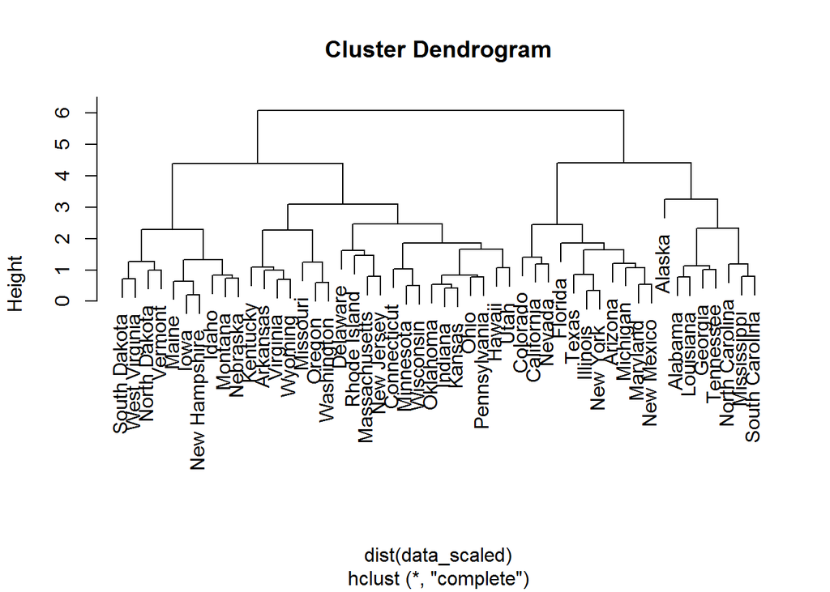

```r
data_scaled <- scale(USArrests)
hc_sd <- hclust(dist(data_scaled), method = "complete")
plot(hc_sd)
```

#### d) What effect does scaling the variables have on the hierarchical clustering obtained ? In your opinion,

#### should the variables be scaled before the inter-observation dissimilarities are computed ? Provide a justification for your answer.

```r
cut <- cutree(hc_sd, 3)
table(cutree(hc_all, 3), cutree(hc_sd, 3))
```

```
FALSE
FALSE      1  2  3
FALSE   1  6  9  1
FALSE   2  2  2 10
FALSE   3  0  0 20
```

#### It is important to scale the variables so they have the same mean and variance since they have are in different units.

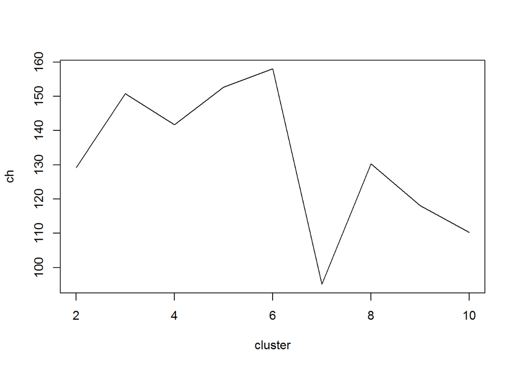

```r
ch_df <- data.frame()

for(i in 2:10){
  km <- kmeans(USArrests, centers=i)
    ch_df<- rbind(ch_df, cbind(i, calinhara(USArrests,km$cluster)))
}
names(ch_df) <- c("cluster", "ch")
plot(ch_df, type='l')
```

```r
table(cutree(hc_all, 6), kmeans(USArrests, centers=6)$cluster)
```

```
FALSE
FALSE      1  2  3  4  5  6
FALSE   1  0  4  0  0  0 10
FALSE   2  0  0  0  5  0  1
FALSE   3  0  0 10  0  0  0
FALSE   4  0  2  0  0  0  0
FALSE   5  4  0  0  0  6  0
FALSE   6  0  0  0  8  0  0
```